# ECO232 Rを使った経済データの収集と分析の方法

鈴木寛（Hiroshi Suzuki）

2023-02-21

# 1 DAY 1：2月20日

## 1.1 RStudio で Project の作成

### 1.1.1 確認

1. R と R Studio のインストール
2. RStudio: New Project 作成
- R Studio の起動
- New Project: eco232, eco232.Rproj
3. Save して、終了
4. プロジェクトを起動確認

## 1.2 基本コマンド - in Console

- `head(cars)`
- `str(cars)`
- `summary(cars)`
- `df_cars <- cars`
  - `<-` と `_` と `%>%` と ` back tick の確認
- `View(cars)` または、右上の Environment から、`df_cars` をクリック
- `?cars` または Help 検索窓で `cars`, `head` など

おすすめ：`Sys.setenv(LANG = "en")`

## 1.3 Package の確認とインストール

R packages are extensions to the R statistical programming language containing code, data, and documentation in a standardised collection format that can be installed by users of R using Tool > Install Packages in the top menu bar of R Studio.

Rパッケージは、Rの拡張機能で、コード、データ、ドキュメントを標準化されたコレクション形式で含んでおり、標準的なものは、R Studio の Top Bar の Tool > Install Packages からインストールできます。

- Minimum: `tidyverse`, `rmarkdown`, `WDI`

あとから使うので、ロードしておきます。最初に次のようなコードを実行します。右の三角を押します。

```r
library(tidyverse)
library(WDI)
```

## 1.4 R Markdown 入門

### 1.4.1 R Notebook

R Markdownはデータサイエンスのためのオーサリングフレームワーク。

コード（プログラム）とその実行結果、を記録・表示し、高品質のレポートの作成を可能にします。

R Notebook は、独立してインタラクティブに実行できるチャンクを持つR Markdownドキュメントの一つの形式で、入力のすぐ下に出力が表示することができます。

1. File > New File > R Notebook
2. Save with a file name, say, test-notebook
3. Preview by [Preview] button
4. Run Code Chunk plot(cars) and then Preview again.

## 1.5 World Development Indicator (WDI)

```r
WDI(country = "all", indicator = c(gdp = "NY.GDP.MKTP.CD"),
    extra=TRUE) %>% drop_na(gdp) %>%
  filter(year==max(year), income !="Aggregates") %>%
  drop_na(region) %>% arrange(desc(gdp))
```

| country | iso2c | iso3c | year | gdp | status | lastupdated | region | capital | longitude | latitude | income | lending |
| --- | --- | --- | --- | --- | --- | --- | --- | --- | --- | --- | --- | --- |
| United States | US | USA | 2021 | 2.331508e+13 |  | 2022-12-22 | North America | Washington D.C. | -77.032 | 38.8895 | High income | Not classified |
| China | CN | CHN | 2021 | 1.773406e+13 |  | 2022-12-22 | East Asia & Pacific | Beijing | 116.286 | 40.0495 | Upper middle income | IBRD |
| Japan | JP | JPN | 2021 | 4.940878e+12 |  | 2022-12-22 | East Asia & Pacific | Tokyo | 139.77 | 35.67 | High income | Not classified |
| Germany | DE | DEU | 2021 | 4.259935e+12 |  | 2022-12-22 | Europe & Central Asia | Berlin | 13.4115 | 52.5235 | High income | Not classified |
| India | IN | IND | 2021 | 3.176295e+12 |  | 2022-12-22 | South Asia | New Delhi | 77.225 | 28.6353 | Lower middle income | IBRD |
| United Kingdom | GB | GBR | 2021 | 3.131378e+12 |  | 2022-12-22 | Europe & Central Asia | London | -0.126236 | 51.5002 | High income | Not classified |
| France | FR | FRA | 2021 | 2.957880e+12 |  | 2022-12-22 | Europe & Central Asia | Paris | 2.35097 | 48.8566 | High income | Not classified |
| Italy | IT | ITA | 2021 | 2.107703e+12 |  | 2022-12-22 | Europe & Central Asia | Rome | 12.4823 | 41.8955 | High income | Not classified |
| Canada | CA | CAN | 2021 | 1.988336e+12 |  | 2022-12-22 | North America | Ottawa | -75.6919 | 45.4215 | High income | Not classified |
| Korea, Rep. | KR | KOR | 2021 | 1.810956e+12 |  | 2022-12-22 | East Asia & Pacific | Seoul | 126.957 | 37.5323 | High income | Not classified |

[output cut: 186 more lines]

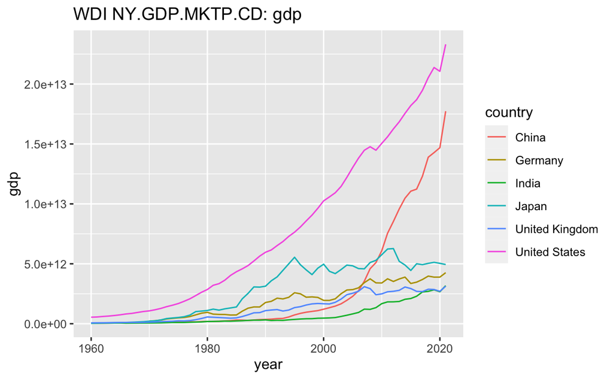

```r
chosen_countries <- c("United States","China", "Japan", "Germany", "United Kingdom","India")
WDI(country = c("CN","GB","JP","IN","US","DE"), indicator = c(gdp = "NY.GDP.MKTP.CD"), extra=TRUE) %>% drop_na(gdp) %>%
  ggplot(aes(year, gdp, col = country)) + geom_line() +
  labs(title = "WDI NY.GDP.MKTP.CD: gdp")
```

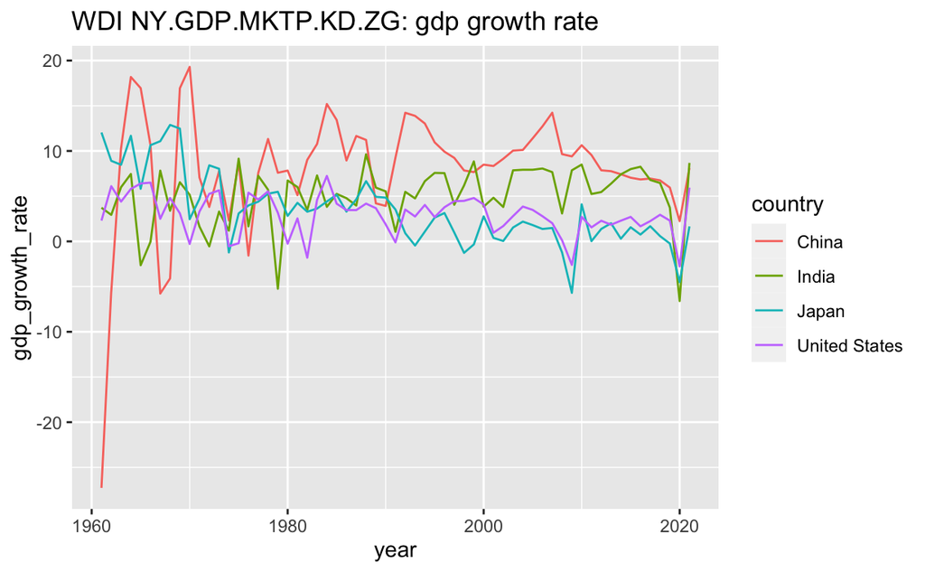

```r
WDI(country = c("CN","IN","JP","US"),
    indicator = c(gdp_growth_rate = "NY.GDP.MKTP.KD.ZG"), extra=TRUE) %>%
  drop_na(gdp_growth_rate) %>%
  ggplot(aes(year, gdp_growth_rate, col = country)) + geom_line() +
  labs(title = paste("WDI NY.GDP.MKTP.KD.ZG: gdp growth rate"))
```

### 1.5.1 指標 Indicators (WDI)

- NY.GDP.MKTP.CD: GDP (current US$)
- NY.GDP.MKTP.KD.ZG: GDP growth (annual %)

### 1.5.2 指標 WDI を探してみよう

> The World Development Indicators is a compilation of relevant, high-quality, and internationally comparable statistics about global development and the fight against poverty. The database contains 1,400 time series indicators for 217 economies and more than 40 country groups, with data for many indicators going back more than 50 years.

> WDIは、世界の開発状況と、貧困との戦いに関する、適切で上質、かつ、国際的に比較可能な時系列の統計データを編纂したものです。このデータベースは、217の経済と40以上の国グループについて1,400の時系列指標を含み、指標のデータの多くは50年以上前に遡ることができます。
- 世界銀行（World Bank）:
- World Bank Open Data:
  - Country / Indicator > Featured & All > Details
- [World Development Indicators (WDI)](https://datatopics.worldbank.org/world-development-indicators/) :
  - Themes: Poverty and Inequality, People, Environment, Economy, States and Markets, Global Links
  - Open Data & DataBank: Explore data, Query database

### 1.5.3 指標 WDIの例

- NY.GDP.MKTP.CD: GDP (current US$)
- NY.GDP.DEFL.KD.ZG: Inflation, GDP deflator (annual %)
- SL.UEM.TOTL.NE.ZS: Unemployment, total (% of total labor force) (national estimate)
- CPTOTNSXN: CPI Price, nominal
- SL.TLF.CACT.MA.NE.ZS: Labor force participation rate, male (% of male population ages 15+) (national estimate)
- SL.TLF.CACT.FE.NE.ZS: Labor force participation rate, female (% of male population ages 15+) (national estimate)

### 1.5.4 練習 1. - 調べてみたい WDI

いくつか、リストしてみましょう。

## 1.6 WDI パッケージ

`WDI` パッケージで、データをダウンロードしたり、探したり、詳細情報を得たりできます。

### 1.6.1 指標 WDI 検索

#### 1.6.1.1 検索例 1（WDI名）

```r
WDIsearch(string = "gdp", field = "name", short = TRUE, cache = NULL)
```

|  | indicator | name |
| --- | --- | --- |
| 712 | 5.51.01.10.gdp | Per capita GDP growth |
| 714 | 6.0.GDP_current | GDP (current $) |
| 715 | 6.0.GDP_growth | GDP growth (annual %) |
| 716 | 6.0.GDP_usd | GDP (constant 2005 $) |
| 717 | 6.0.GDPpc_constant | GDP per capita, PPP (constant 2011 international $) |
| 1557 | BG.GSR.NFSV.GD.ZS | Trade in services (% of GDP) |
| 1558 | BG.KAC.FNEI.GD.PP.ZS | Gross private capital flows (% of GDP, PPP) |
| 1559 | BG.KAC.FNEI.GD.ZS | Gross private capital flows (% of GDP) |
| 1560 | BG.KLT.DINV.GD.PP.ZS | Gross foreign direct investment (% of GDP, PPP) |
| 1561 | BG.KLT.DINV.GD.ZS | Gross foreign direct investment (% of GDP) |

[output cut: 530 more lines]

#### 1.6.1.2 検索例 2（WDI）

```r
WDIsearch(string = "NY.GDP.MKTP.CD", field = "indicator", short = TRUE, cache = NULL)
```

|  | indicator | name |
| --- | --- | --- |
| 11410 | NY.GDP.MKTP.CD | GDP (current US$) |
| 11411 | NY.GDP.MKTP.CD.XD | GDP deflator, index (2000=100; US$ series) |

#### 1.6.1.3 練習 2. - 検索（short）

名前で検索（“” の間に、（なるべく簡単な）検索文字列を入れてください。）

```r
WDIsearch(string = "", field = "name", short = TRUE, cache = NULL)
```

Indicator で検索（“” の間に、調べたい indicator を入れてください。）

```r
WDIsearch(string = "", field = "indicator", short = TRUE, cache = NULL)
```

#### 1.6.1.4 詳しい情報を得るには

`short = FALSE` とします。時間がかかるので、検索は、Indicator と、名前などの情報をもったファイルを手元に持っておくことにします。

```r
wdi_cache <- WDIcache()
```

右上の窓枠（pane）から、`wdi_cache` を探して、中身を見てみましょう。series と、country の二つのデータ・フレームからなっているリストです。三角印や、右から二番目の巻物のようなアイコンをクリックすると中身が見えます。

#### 1.6.1.5 検索例 3（WDI名）

```r
WDIsearch(string = "CPI Price", field = "name", short = FALSE, cache = wdi_cache)
```

|  | indicator | name | description | sourceDatabase | sourceOrganization |
| --- | --- | --- | --- | --- | --- |
| 2586 | CPTOTNSXN | CPI Price, nominal | The consumer price index reflects the change in prices for the average consumer of a constant basket of consumer goods. Data is not seasonally adjusted. | Global Economic Monitor | World Bank staff calculations based on Datastream data. |
| 2587 | CPTOTSAXMZGY | CPI Price, % y-o-y, median weighted, seas. adj. | Median inflation rate calculated for geographical aggregates (regions, world, etc) of the annual percent change of the CPI. Data is seasonally adjusted. | Global Economic Monitor | World Bank staff calculations based on Datastream data. |
| 2588 | CPTOTSAXN | CPI Price, nominal, seas. adj. | The consumer price index reflects the change in prices for the average consumer of a constant basket of consumer goods. Data is in nominal terms and seasonally adjusted. | Global Economic Monitor | World Bank staff calculations based on Datastream data. |
| 2589 | CPTOTSAXNZGY | CPI Price, % y-o-y, nominal, seas. adj. | The consumer price index reflects the change in prices for the average consumer of a constant basket of consumer goods. Data is in nominal percentage terms, measured on a year-on-year basis, and seaso… | Global Economic Monitor | World Bank staff calculations based on Datastream data. |

- CPTOTNSXN: CPI Price, nominal
  - The consumer price index reflects the change in prices for the average consumer of a constant basket of consumer goods. Data is not seasonally adjusted.

#### 1.6.1.6 検索例 4（WDI）

```r
WDIsearch(string = "NY.GDP.MKTP.KD.ZG", field = "indicator", short = FALSE, cache = wdi_cache)
```

|  | indicator | name | description | sourceDatabase | sourceOrganization |
| --- | --- | --- | --- | --- | --- |
| 12114 | NY.GDP.MKTP.KD.ZG | GDP growth (annual %) | Annual percentage growth rate of GDP at market prices based on constant local currency. Aggregates are based on constant 2015 prices, expressed in U.S. dollars. GDP is the sum of gross value added by … | World Development Indicators | World Bank national accounts data, and OECD National Accounts data files. |

#### 1.6.1.7 練習 2 - 検索（long w/ cache）

`string` と、`field` を、ふたつとも入れてください。

```r
WDIsearch(string = "", field = "", short = FALSE, cache = wdi_cache)
```

### 1.6.2 指標 WDI データのダウンロード

Indicator が決まったら、ダウンロードします。

```r
?WDI
```

#### 1.6.2.1 ダウンロード例 1-1

```r
df_gdp1 <- WDI(country = "all", indicator = "NY.GDP.MKTP.CD")
df_gdp1
```

| country | iso2c | iso3c | year | NY.GDP.MKTP.CD |
| --- | --- | --- | --- | --- |
| Africa Eastern and Southern | ZH | AFE | 2021 | 1.080712e+12 |
| Africa Eastern and Southern | ZH | AFE | 2020 | 9.274845e+11 |
| Africa Eastern and Southern | ZH | AFE | 2019 | 1.001017e+12 |
| Africa Eastern and Southern | ZH | AFE | 2018 | 1.007240e+12 |
| Africa Eastern and Southern | ZH | AFE | 2017 | 1.021119e+12 |
| Africa Eastern and Southern | ZH | AFE | 2016 | 8.827213e+11 |
| Africa Eastern and Southern | ZH | AFE | 2015 | 9.245228e+11 |
| Africa Eastern and Southern | ZH | AFE | 2014 | 1.003768e+12 |
| Africa Eastern and Southern | ZH | AFE | 2013 | 9.834729e+11 |
| Africa Eastern and Southern | ZH | AFE | 2012 | 9.725734e+11 |

[output cut: 990 more lines]

#### 1.6.2.2 ダウンロード例 1-2

```r
df_gdp2 <- WDI(country = "all", indicator = c(gdp = "NY.GDP.MKTP.CD"))
df_gdp2
```

| country | iso2c | iso3c | year | gdp |
| --- | --- | --- | --- | --- |
| Africa Eastern and Southern | ZH | AFE | 2021 | 1.080712e+12 |
| Africa Eastern and Southern | ZH | AFE | 2020 | 9.274845e+11 |
| Africa Eastern and Southern | ZH | AFE | 2019 | 1.001017e+12 |
| Africa Eastern and Southern | ZH | AFE | 2018 | 1.007240e+12 |
| Africa Eastern and Southern | ZH | AFE | 2017 | 1.021119e+12 |
| Africa Eastern and Southern | ZH | AFE | 2016 | 8.827213e+11 |
| Africa Eastern and Southern | ZH | AFE | 2015 | 9.245228e+11 |
| Africa Eastern and Southern | ZH | AFE | 2014 | 1.003768e+12 |
| Africa Eastern and Southern | ZH | AFE | 2013 | 9.834729e+11 |
| Africa Eastern and Southern | ZH | AFE | 2012 | 9.725734e+11 |

[output cut: 990 more lines]

#### 1.6.2.3 ダウンロード例 1-3

```r
df_gdp3 <- WDI(country = "all", indicator = c(gdp = "NY.GDP.MKTP.CD"), extra=TRUE, cache=wdi_cache)
df_gdp3
```

| country | iso2c | iso3c | year | gdp | status | lastupdated | region | capital | longitude | latitude | income | lending |
| --- | --- | --- | --- | --- | --- | --- | --- | --- | --- | --- | --- | --- |
| Afghanistan | AF | AFG | 2021 | 1.478686e+10 |  | 2022-12-22 | South Asia | Kabul | 69.1761 | 34.5228 | Low income | IDA |
| Afghanistan | AF | AFG | 2020 | 2.014344e+10 |  | 2022-12-22 | South Asia | Kabul | 69.1761 | 34.5228 | Low income | IDA |
| Afghanistan | AF | AFG | 2019 | 1.890449e+10 |  | 2022-12-22 | South Asia | Kabul | 69.1761 | 34.5228 | Low income | IDA |
| Afghanistan | AF | AFG | 2018 | 1.841885e+10 |  | 2022-12-22 | South Asia | Kabul | 69.1761 | 34.5228 | Low income | IDA |
| Afghanistan | AF | AFG | 2017 | 1.889635e+10 |  | 2022-12-22 | South Asia | Kabul | 69.1761 | 34.5228 | Low income | IDA |
| Afghanistan | AF | AFG | 2016 | 1.801956e+10 |  | 2022-12-22 | South Asia | Kabul | 69.1761 | 34.5228 | Low income | IDA |
| Afghanistan | AF | AFG | 2015 | 1.999816e+10 |  | 2022-12-22 | South Asia | Kabul | 69.1761 | 34.5228 | Low income | IDA |
| Afghanistan | AF | AFG | 2014 | 2.055058e+10 |  | 2022-12-22 | South Asia | Kabul | 69.1761 | 34.5228 | Low income | IDA |
| Afghanistan | AF | AFG | 2013 | 2.056449e+10 |  | 2022-12-22 | South Asia | Kabul | 69.1761 | 34.5228 | Low income | IDA |
| Afghanistan | AF | AFG | 2012 | 2.020357e+10 |  | 2022-12-22 | South Asia | Kabul | 69.1761 | 34.5228 | Low income | IDA |

[output cut: 990 more lines]

#### 1.6.2.4 ダウンロード例 1-4

```r
df_gdp4 <- WDI(country = c("CN","GB","JP","IN","US","DE"), indicator = c(gdp = "NY.GDP.MKTP.CD"), extra=TRUE, cache=wdi_cache)
df_gdp4
```

| country | iso2c | iso3c | year | gdp | status | lastupdated | region | capital | longitude | latitude | income | lending |
| --- | --- | --- | --- | --- | --- | --- | --- | --- | --- | --- | --- | --- |
| China | CN | CHN | 2021 | 1.773406e+13 |  | 2022-12-22 | East Asia & Pacific | Beijing | 116.286 | 40.0495 | Upper middle income | IBRD |
| China | CN | CHN | 2020 | 1.468767e+13 |  | 2022-12-22 | East Asia & Pacific | Beijing | 116.286 | 40.0495 | Upper middle income | IBRD |
| China | CN | CHN | 2019 | 1.427994e+13 |  | 2022-12-22 | East Asia & Pacific | Beijing | 116.286 | 40.0495 | Upper middle income | IBRD |
| China | CN | CHN | 2018 | 1.389482e+13 |  | 2022-12-22 | East Asia & Pacific | Beijing | 116.286 | 40.0495 | Upper middle income | IBRD |
| China | CN | CHN | 2017 | 1.231041e+13 |  | 2022-12-22 | East Asia & Pacific | Beijing | 116.286 | 40.0495 | Upper middle income | IBRD |
| China | CN | CHN | 2016 | 1.123328e+13 |  | 2022-12-22 | East Asia & Pacific | Beijing | 116.286 | 40.0495 | Upper middle income | IBRD |
| China | CN | CHN | 2015 | 1.106155e+13 |  | 2022-12-22 | East Asia & Pacific | Beijing | 116.286 | 40.0495 | Upper middle income | IBRD |
| China | CN | CHN | 2014 | 1.047568e+13 |  | 2022-12-22 | East Asia & Pacific | Beijing | 116.286 | 40.0495 | Upper middle income | IBRD |
| China | CN | CHN | 2013 | 9.570406e+12 |  | 2022-12-22 | East Asia & Pacific | Beijing | 116.286 | 40.0495 | Upper middle income | IBRD |
| China | CN | CHN | 2012 | 8.532230e+12 |  | 2022-12-22 | East Asia & Pacific | Beijing | 116.286 | 40.0495 | Upper middle income | IBRD |

[output cut: 362 more lines]

#### 1.6.2.5 ダウンロード例 2-1

- NY.GDP.DEFL.KD.ZG: Inflation, GDP deflator (annual %)
- CPTOTNSXN: CPI Price, nominal

```r
df_gdp21 <- WDI(country = "all",
                indicator = c(gdp_deflator = "NY.GDP.DEFL.KD.ZG",
                              cpi_price = "CPTOTNSXN"),
                extra=TRUE, cache=wdi_cache)
df_gdp21
```

| country | iso2c | iso3c | year | status | lastupdated | gdp_deflator | cpi_price | region | capital | longitude | latitude | income | lending |
| --- | --- | --- | --- | --- | --- | --- | --- | --- | --- | --- | --- | --- | --- |
| Advanced Economies | AME |  | 1987 |  | 2020-07-27 | NA | 58.7090767 | NA | NA | NA | NA | NA | NA |
| Advanced Economies | AME |  | 1988 |  | 2020-07-27 | NA | 60.5099755 | NA | NA | NA | NA | NA | NA |
| Advanced Economies | AME |  | 1989 |  | 2020-07-27 | NA | 63.0162118 | NA | NA | NA | NA | NA | NA |
| Advanced Economies | AME |  | 1990 |  | 2020-07-27 | NA | 66.0361058 | NA | NA | NA | NA | NA | NA |
| Advanced Economies | AME |  | 1991 |  | 2020-07-27 | NA | 69.1080142 | NA | NA | NA | NA | NA | NA |
| Advanced Economies | AME |  | 1992 |  | 2020-07-27 | NA | 71.4318951 | NA | NA | NA | NA | NA | NA |
| Advanced Economies | AME |  | 1993 |  | 2020-07-27 | NA | 73.5839345 | NA | NA | NA | NA | NA | NA |
| Advanced Economies | AME |  | 1994 |  | 2020-07-27 | NA | 75.3508272 | NA | NA | NA | NA | NA | NA |
| Advanced Economies | AME |  | 1995 |  | 2020-07-27 | NA | 77.1273689 | NA | NA | NA | NA | NA | NA |
| Advanced Economies | AME |  | 1996 |  | 2020-07-27 | NA | 78.8553356 | NA | NA | NA | NA | NA | NA |

[output cut: 990 more lines]

```r
str(df_gdp21)
```

```
'data.frame':   23972 obs. of  14 variables:
 $ country     : chr  "Advanced Economies" "Advanced Economies" "Advanced Economies" "Advanced Economies" ...
 $ iso2c       : chr  "AME" "AME" "AME" "AME" ...
 $ iso3c       : chr  "" "" "" "" ...
 $ year        : int  1987 1988 1989 1990 1991 1992 1993 1994 1995 1996 ...
 $ status      : chr  "" "" "" "" ...
 $ lastupdated : chr  "2020-07-27" "2020-07-27" "2020-07-27" "2020-07-27" ...
 $ gdp_deflator: num  NA NA NA NA NA NA NA NA NA NA ...
  ..- attr(*, "label")= chr "Inflation, GDP deflator (annual %)"
 $ cpi_price   : num  58.7 60.5 63 66 69.1 ...
  ..- attr(*, "label")= chr "CPI Price,not seas.adj,,,"
 $ region      : chr  NA NA NA NA ...
 $ capital     : chr  NA NA NA NA ...
 $ longitude   : chr  NA NA NA NA ...
 $ latitude    : chr  NA NA NA NA ...
 $ income      : chr  NA NA NA NA ...
 $ lending     : chr  NA NA NA NA ...
```

```r
summary(df_gdp21)
```

```
   country             iso2c              iso3c                year
 Length:23972       Length:23972       Length:23972       Min.   :1960
 Class :character   Class :character   Class :character   1st Qu.:1982
 Mode  :character   Mode  :character   Mode  :character   Median :1996
                                                          Mean   :1995
                                                          3rd Qu.:2009
                                                          Max.   :2021

    status          lastupdated         gdp_deflator         cpi_price
 Length:23972       Length:23972       Min.   :  -98.704   Min.   :  0.00
 Class :character   Class :character   1st Qu.:    2.317   1st Qu.: 55.95
 Mode  :character   Mode  :character   Median :    5.273   Median : 83.28
                                       Mean   :   25.308   Mean   : 84.18
                                       3rd Qu.:   10.411   3rd Qu.:108.75
                                       Max.   :26765.858   Max.   :551.25
                                       NA's   :11616       NA's   :18410
    region            capital           longitude           latitude
 Length:23972       Length:23972       Length:23972       Length:23972
 Class :character   Class :character   Class :character   Class :character
 Mode  :character   Mode  :character   Mode  :character   Mode  :character




    income            lending
 Length:23972       Length:23972
 Class :character   Class :character
 Mode  :character   Mode  :character
```

右上の窓枠の、Environment も見てみましょう。

## 1.7 可視化 Visualization

グラフ（Chart）を描いて視覚化しよう

### 1.7.1 グラフ 1

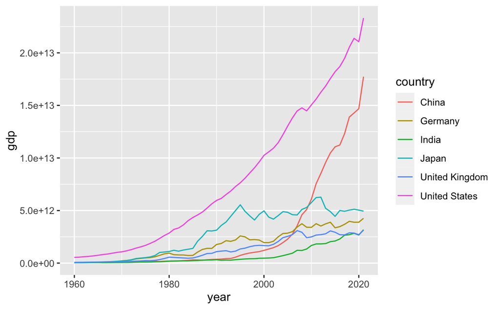

```r
df_gdp4 %>% ggplot(aes(year, gdp, col=country)) + geom_line()
```

### 1.7.2 グラフ 2

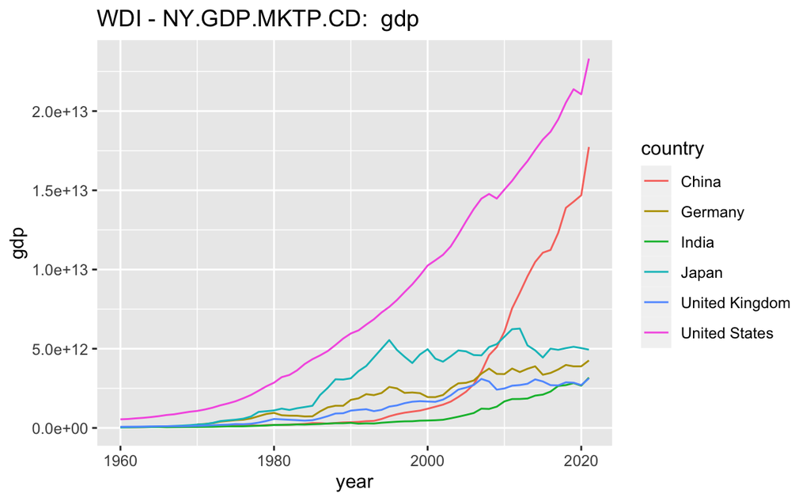

```r
df_gdp4 %>% drop_na(gdp) %>%
  ggplot(aes(year, gdp, col=country)) + geom_line() +
  labs(title = paste("WDI - NY.GDP.MKTP.CD: ", "gdp"))
```

### 1.7.3 テンプレート Templates

#### 1.7.3.1 一つの国についての、一つの指標（WDI）と、その略称から、折線グラフを作成

Line Plot with one indicator with abbreviation and one country

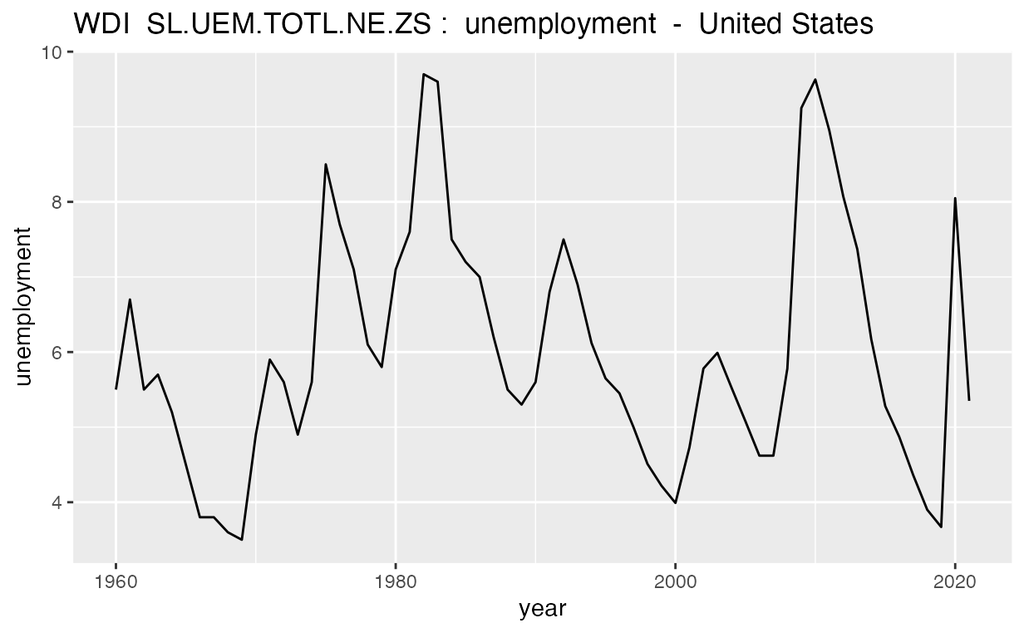

```r
chosen_indicator <- "SL.UEM.TOTL.NE.ZS"
short_name <- "unemployment"
chosen_country <- "United States"
WDI(country = "all", indicator = c(short_name = chosen_indicator), extra=TRUE, cache=wdi_cache) %>%
  filter(country == chosen_country) %>%
  ggplot(aes(year, short_name)) + geom_line() +
  labs(title = paste("WDI ", chosen_indicator, ": ", short_name, " - ", chosen_country),
       y = short_name)
```

#### 1.7.3.2 一つの国についての、一つの指標（WDI）から、折線グラフを作成

Line Plot with one indicator and one country

```r
chosen_indicator <- "SL.UEM.TOTL.NE.ZS"
chosen_country <- "United States"
WDI(country = "all", indicator = c(chosen_indicator = chosen_indicator),
    extra=TRUE, cache=wdi_cache) %>%
  filter(country == chosen_country) %>%
  ggplot(aes(year, chosen_indicator)) + geom_line() +
  labs(title = paste("WDI ", chosen_indicator, " - ", chosen_country),
       y = chosen_indicator)
```

#### 1.7.3.3 いくつかの国についての、一つの指標（WDI）と、その略称から、折線グラフを作成

Line Plot with one indicator with abbreviation and several countries

```r
chosen_indicator <- "SL.UEM.TOTL.NE.ZS"
short_name <- "unemployment"
chosen_countries <- c("United States","United Kingdom", "Japan")
WDI(country = "all", indicator = c(short_name = chosen_indicator), extra=TRUE, cache=wdi_cache) %>% drop_na(short_name) %>%
  filter(country %in% chosen_countries) %>%
  ggplot(aes(year, short_name, col = country)) + geom_line() +
  labs(title = paste("WDI ", chosen_indicator, ": ", short_name), y = short_name)
```

#### 1.7.3.4 一つの国についての、二つの指標（WDI）と、その略称から、折線グラフを作成

Line Plot with two indicators with abbreviation and one country

```r
chosen_indicator_1 <- "NY.GDP.DEFL.KD.ZG"
short_name_1 <- "gdp_deflator"
chosen_indicator_2 <- "CPTOTSAXNZGY"
short_name_2 <- "cpi_price"
chosen_country <- "United States"
WDI(country = "all", indicator = c(short_name_1 = chosen_indicator_1, short_name_2 = chosen_indicator_2), extra=TRUE, cache=wdi_cache) %>%
  filter(country == chosen_country) %>%
  pivot_longer(c(short_name_1, short_name_2), names_to = "class", values_to = "value") %>% drop_na(value) %>%
  ggplot(aes(year, value, col = class)) + geom_line() +
  labs(title = paste("WDI ", chosen_indicator_1, ": ", short_name_1, "\n", chosen_indicator_2, ": ", short_name_2, " - ", chosen_country)) +
  scale_color_manual(labels = c(short_name_1, short_name_2), values = scales::hue_pal()(2))
```

```r
chosen_indicator_1 <- "SL.TLF.CACT.MA.NE.ZS"
short_name_1 <- "male"
chosen_indicator_2 <- "SL.TLF.CACT.FE.NE.ZS"
short_name_2 <- "female"
chosen_country <- "United States"
WDI(country = "all", indicator = c(short_name_1 = chosen_indicator_1, short_name_2 = chosen_indicator_2), extra=TRUE, cache=wdi_cache) %>%
  filter(country == chosen_country) %>%
  pivot_longer(c(short_name_1, short_name_2), names_to = "class", values_to = "value") %>% drop_na(value) %>%
  ggplot(aes(year, value, col = class)) + geom_line() +
  labs(title = paste("WDI ", chosen_indicator_1, ": ", short_name_1, "\n", chosen_indicator_2, ": ", short_name_2, " - ", chosen_country)) +
  scale_color_manual(labels = c(short_name_1, short_name_2), values = scales::hue_pal()(2))
```

#### 1.7.3.5 いくつかの国についての、二つの指標（WDI）と、その略称から、折線グラフを作成

Line Plot with two indicators with abbreviation and several countries

```r
chosen_indicator_1 <- "NY.GDP.DEFL.KD.ZG"
short_name_1 <- "gdp_deflator"
chosen_indicator_2 <- "CPTOTSAXNZGY"
short_name_2 <- "cpi_price"
chosen_countries <- c("United States", "France", "Japan")
WDI(country = "all", indicator = c(short_name_1 = chosen_indicator_1, short_name_2 = chosen_indicator_2), extra=TRUE, cache=wdi_cache) %>%
  filter(country %in% chosen_countries) %>%
  pivot_longer(c(short_name_1, short_name_2), names_to = "class", values_to = "value") %>% drop_na(value) %>%
  ggplot(aes(year, value, linetype = class, col = country)) + geom_line() +
  labs(title = paste("WDI ", chosen_indicator_1, ": ", short_name_1, "\n", chosen_indicator_2, ": ", short_name_2)) +
  scale_linetype_manual(labels = c(short_name_1, short_name_2), values = c("solid", "dashed"))
```

```r
chosen_indicator_1 <- "SL.TLF.CACT.MA.NE.ZS"
short_name_1 <- "male"
chosen_indicator_2 <- "SL.TLF.CACT.FE.NE.ZS"
short_name_2 <- "female"
chosen_countries <- c("United States", "France", "Japan")
WDI(country = "all", indicator = c(short_name_1 = chosen_indicator_1, short_name_2 = chosen_indicator_2), extra=TRUE, cache=wdi_cache) %>%
  filter(country %in% chosen_countries) %>%
  pivot_longer(c(short_name_1, short_name_2), names_to = "class", values_to = "value") %>% drop_na(value) %>%
  ggplot(aes(year, value, linetype = class, col = country)) + geom_line() +
  labs(title = paste("WDI ", chosen_indicator_1, ": ", short_name_1, "\n", chosen_indicator_2, ": ", short_name_2)) +
  scale_linetype_manual(labels = c(short_name_1, short_name_2), values = c("solid", "dashed"))
```

## 1.8 課題 Assignment

上のテンプレートをコピーして、下に貼り付け、指標 `indicator` と、略称 `short_name` と、いくつかの国名 `chosen_countries` を、入れ替えて、試してみてください。